# PD5

Rafał Kobiela

Listopad 17, 2018

## Opis zadania

Zadaniem w tej pracy domowej było przeprowadzenie eksperymentu polegającego na sprawdzeniu, czy błędy w odczytywaniu niektórych wykresów rzeczywiście występują. Jako rodzaj wykresu do testów wybrałem wykres kołowy 3D.

## Opis eksperymentu

Na wykresie został przedstawiony udział procentowy w sprzedaży pralek w Polsce w 2015 roku. Dane zostały wymyślone na potrzeby tego ćwiczenia. Dane te możemy dobrze zaprezentować przy pomocy wykresu słupkowego.

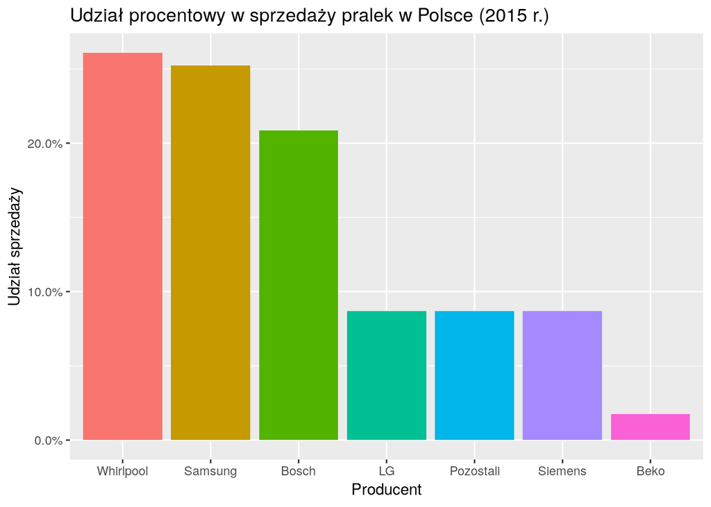

W eksperymencie zaprezentowałem dane w następujący sposób.

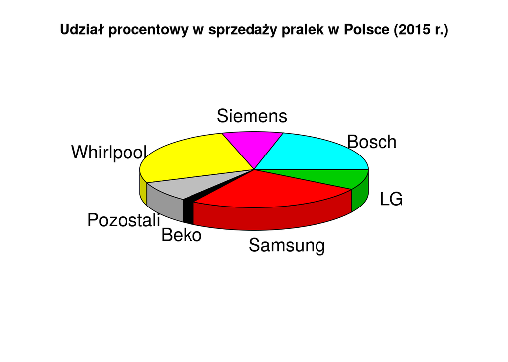

Jak widać, nie jest on już tak czytelny. Do przeprowadzenmia ankiety użyłem ankiety znajdujęcej się pod linkiem: https://goo.gl/forms/qVTY6mGjTMIeR6bx2 Na pytania odpowiedziały 52 osoby.

### Pytanie 1

Brzmiało ono następująco: “Która firma odnotowała największy udział w sprzedaży w 2015 roku?” Na wykresie słupkowym widać, bez wątpienia, że największy udział miała firma Whirlpool. Na wykresie kołowym już nie jest to takie oczywiste. Wyniki pytania prezentują się następująco:

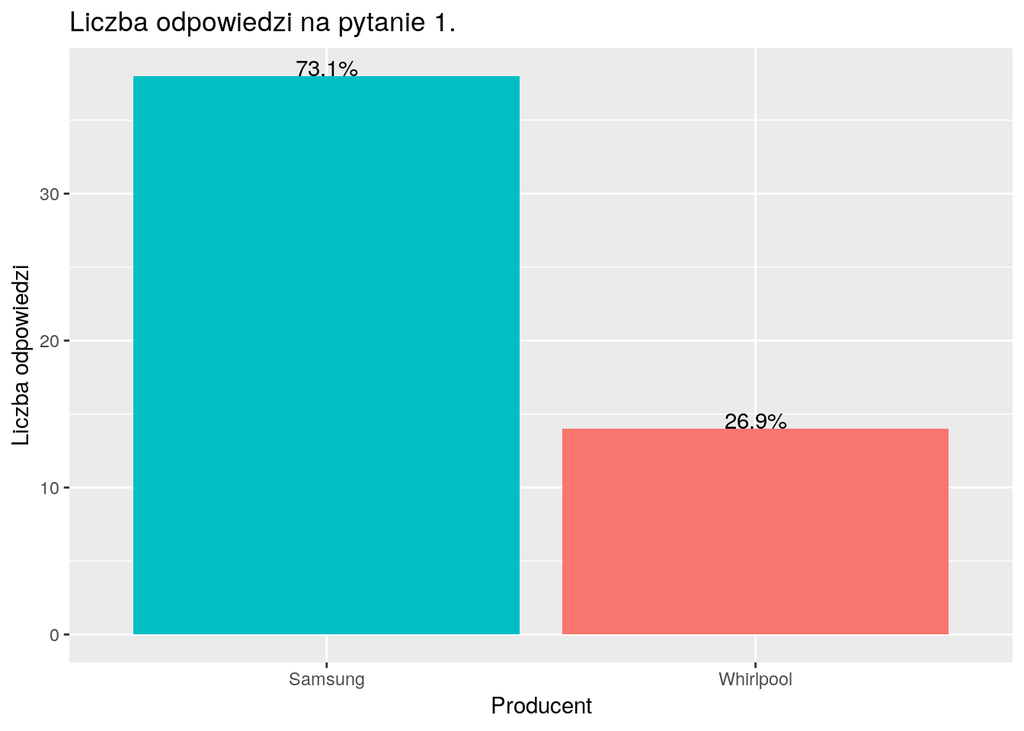

Widać, że aż 73.1% osób odpowiedziało, że największy udział w sprzedaży miał Samsung, mimo, że to nie jest prawda. Jak widać bład poznawczy występuje.

### Pytanie 2

Brzmiało ono następująco: “Wybierz odpowiedź, w której wybrani producenci są uszeregowani względem udziału od najmniejszego do największego.” Mieliśmy do wyboru tylko Siemensa, LG oraz Pozostałych producentów. Na wykresie słupkowym widać, że wszyscy trzej producenci mają taki sam udział. Gdyby każdy z wycinków koła wydawał się tak sam statystycznie na każdą odpowowiedź zagłosowałoby tyle samo osób. Tak się jednak nie stało co przedstawia poniższy wykres.

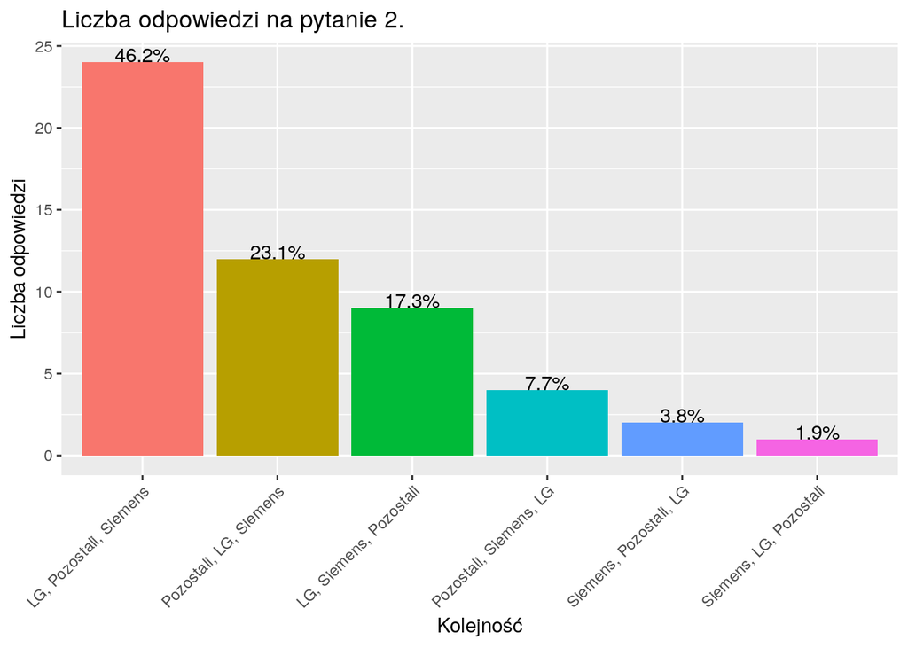

Widać, że na odpowiedź LG, Pozostali, Siemens odpowiedziało aż 46.2% ankietowanych. Druga w kolejności odpowiedź to Pozostali, LG, Siemens gdzie również Siemens wydaje się być dla ankietowanych producentem z największym udziałem.

## Podsumowanie

Widać, że w obydwu pytaniach odpowiedzi wskazują na błędy poznawcze przy odczytywaniu wykresu. Najpierw ludzie źle odczytują największego gracza na rynku pralek a następnie prawie połowie osób wydaje się, że kolejność na którą załosowali jest poprawna, mimo że wszyscy prodycenci mają taki sam udział.